# Lab 08 - Predicting rain

KEY

2025-11-13

### Load packages

```r
library(tidyverse)
library(tidymodels)
library(patchwork)
```

### Read in data

```r
weather <- read.csv("data/weatherAUS.csv", header = TRUE)
```

# Exercise 1: Exploratory Data Analysis

We will start by transform any character variables that need to be transformed into categorical. Use the following code to identify them and trasform them into factors.

```r
variables_to_transform = weather %>%
  select(where(is.character),-Date) %>% names()
weather <- weather %>%
  mutate_at(vars(all_of(variables_to_transform)),factor)
```

To simplify things, today we will not be using some categorical explanatory variables, because they have a very large number of categories and might make our model interpretation more complex. Specifically we will exclude `WindGustDir`, `WindDir9am` and `WindDir3pm`.

```r
weather <- weather %>%
  select(-WindGustDir,-WindDir9am,-WindDir3pm)
```

Note that some of these variables have a large number of missing values:

```r
weather %>%
  select(where(~ any(is.na(.)))) %>%
  summarise(across(everything(), ~mean(is.na(.)))) %>%
  pivot_longer(col = everything(), names_to = "Variable", values_to = "Prop_NA") %>%
  arrange(desc(Prop_NA))
```

```
## # A tibble: 18 × 2
##    Variable      Prop_NA
##    <chr>           <dbl>
##  1 Sunshine      0.480
##  2 Evaporation   0.432
##  3 Cloud3pm      0.408
##  4 Cloud9am      0.384
##  5 Pressure9am   0.104
##  6 Pressure3pm   0.103
##  7 WindGustSpeed 0.0706
##  8 Humidity3pm   0.0310
##  9 Temp3pm       0.0248
## 10 RainTomorrow  0.0225
## 11 Rainfall      0.0224
## 12 RainToday     0.0224
## 13 WindSpeed3pm  0.0211
## 14 Humidity9am   0.0182
## 15 WindSpeed9am  0.0121
## 16 Temp9am       0.0121
## 17 MinTemp       0.0102
## 18 MaxTemp       0.00867
```

1. Are there any missing values in our variable of interest `RainTomorrow`? If so, we filter them out and save the new dataset as `weather_noNA`.

Yes, there are 3267 missing cases in `weather`.

```r
weather_noNA <- weather %>%
  filter(!is.na(RainTomorrow))
```

The remainig number of observations in `weather_noNA` are 142193.

2. Which cities are the ones with more rain days? Let’s analyze the `RainToday` variable.

```r
weather_noNA %>% group_by(Location) %>%
  summarize(avg_raindays = mean(RainToday == "Yes", na.rm = TRUE)) %>%
  arrange(desc(avg_raindays))
```

```
## # A tibble: 49 × 2
##    Location      avg_raindays
##    <fct>                <dbl>
##  1 Portland             0.365
##  2 Walpole              0.335
##  3 Cairns               0.317
##  4 Dartmoor             0.313
##  5 NorfolkIsland        0.310
##  6 MountGambier         0.304
##  7 Albany               0.298
##  8 Witchcliffe          0.298
##  9 CoffsHarbour         0.294
## 10 MountGinini          0.277
## # ℹ 39 more rows
```

# Exercise 2: Logistic regression

We will focus our analysis on the city of `Portland`.

```r
weather_Portland <- weather_noNA %>%
  filter(Location == "Portland")
```

```r
Portland_fit <- logistic_reg() %>%
  set_engine("glm") %>%
  fit(RainTomorrow ~ RainToday,
      data = weather_Portland, family = "binomial")

tidy(Portland_fit)
```

```
## # A tibble: 2 × 5
##   term         estimate std.error statistic  p.value
##   <chr>           <dbl>     <dbl>     <dbl>    <dbl>
## 1 (Intercept)     -1.08    0.0527     -20.4 1.51e-92
## 2 RainTodayYes     1.33    0.0807      16.5 4.39e-61
```

2. For each point in our dataset, what are the fitted probabilities that tomorrow it’s going to rain?
- Plot them using an appropriate visualization. Do you notice anything surprising?

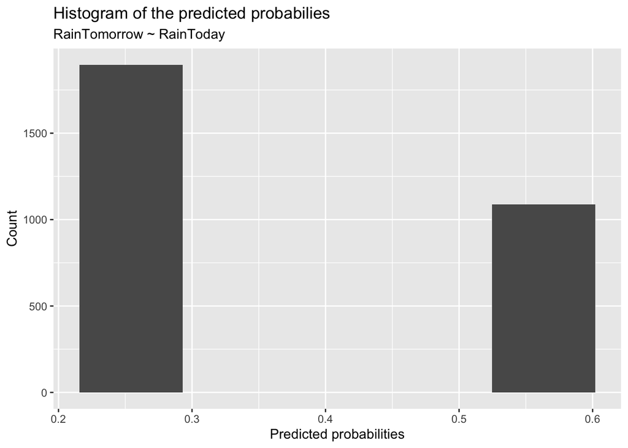

```r
Portland_pred <- predict(Portland_fit, weather_Portland, type = "prob")

ggplot(Portland_pred, aes(x = .pred_Yes)) +
  geom_histogram(bins = 5) +
  labs(x = "Predicted probabilities",
       y = "Count",
       title = "Histogram of the predicted probabilies",
       subtitle = "RainTomorrow ~ RainToday")
```

The predictive probability for each day can only take two values: 0.2542194 or 0.5634191. This is due to the fact that the only explanatory variable `RainToday` is a categorical variable with two levels, so the two probabilities correspond to whether it was raining on that day or not.

- Are there any missing values? Why?

Yes, there are 12 missing values, which correspond to the days where the variable `RainToday` was missing:

```r
weather_Portland %>%
  mutate(Pred_Yes = Portland_pred$.pred_Yes) %>%
  filter(is.na(Pred_Yes)) %>%
  select(RainToday)
```

```
##    RainToday
## 1       <NA>
## 2       <NA>
## 3       <NA>
## 4       <NA>
## 5       <NA>
## 6       <NA>
## 7       <NA>
## 8       <NA>
## 9       <NA>
## 10      <NA>
## 11      <NA>
## 12      <NA>
```

# Exercise 3: Split the data and build workflows

Let us set a seed and perform a split of our data.

```r
set.seed(111723)
```

1. Split the data into a training set (80% of your Portland data) and a testing set.

```r
# Put 80% of the data into the training set
weather_split <- initial_split(weather_Portland, prop = 0.80)
# Create data frames for the two sets:
train_data <- training(weather_split)
test_data  <- testing(weather_split)
```

2. Refit the simple logistic regression using `RainToday` as predictor on this training data, using `tidymodels` recipes and workflows.
- Start by the recipe. First initialize the recipe, then remove observations with missing values using `step_naomit()` and finally use `step_dummy` to convert categorical to dummy variables.

```r
weather_rec1 <- recipe(
  RainTomorrow ~ RainToday,
  data = weather_Portland
  ) %>%
  step_naomit(all_predictors()) %>%
  step_dummy(all_nominal_predictors())
```

- Build your workflow combining model and recipe

```r
weather_mod1 <- logistic_reg() %>%
  set_engine("glm")
weather_wflow1 <- workflow() %>%
  add_model(weather_mod1) %>%
  add_recipe(weather_rec1)
```

- Now fit your model on the training data

```r
weather_fit1 <- weather_wflow1 %>%
  fit(data = train_data)
tidy(weather_fit1)
```

```
## # A tibble: 2 × 5
##   term          estimate std.error statistic  p.value
##   <chr>            <dbl>     <dbl>     <dbl>    <dbl>
## 1 (Intercept)      -1.07    0.0589     -18.1 2.76e-73
## 2 RainToday_Yes     1.33    0.0902      14.7 3.27e-49
```

3. Fit now a multiple logistic regression, i.e. using multiple explanatory variables, to predict `RainTomorrow`. We will use as predictors the variables `MinTemp`, `MaxTemp`, `RainToday` and `Rainfall`. Similarly to question 2, use workflows to fit this model on our training data.
- Start by the recipe. This will be a simple recipe, because we have not done many pre-processing steps, but do remove missing values and transform categorical variables into dummy variables:

```r
weather_rec2 <- recipe(
  RainTomorrow ~ MinTemp+MaxTemp+RainToday+Rainfall, # formula
  data = weather_Portland
  ) %>%
  step_naomit(all_predictors()) %>%
  step_dummy(all_nominal(), -all_outcomes())
```

- Save the model, worflow and finally, let’s fit to the training data:

```r
weather_mod2 <- logistic_reg() %>%
  set_engine("glm")
weather_wflow2 <- workflow() %>%
  add_model(weather_mod2) %>%
  add_recipe(weather_rec2)
weather_fit2 <- weather_wflow2 %>%
  fit(data = train_data)
tidy(weather_fit2)
```

```
## # A tibble: 5 × 5
##   term          estimate std.error statistic       p.value
##   <chr>            <dbl>     <dbl>     <dbl>         <dbl>
## 1 (Intercept)    0.422      0.217      1.94  0.0519
## 2 MinTemp        0.00872    0.0159     0.550 0.582
## 3 MaxTemp       -0.0827     0.0137    -6.06  0.00000000139
## 4 Rainfall       0.0490     0.0124     3.95  0.0000791
## 5 RainToday_Yes  0.715      0.122      5.87  0.00000000436
```

3. Now let’s evaluate the predictive performance of these two models on our test set.
- Create the ROC curve and get the AUC (area under the curve) value for your first simple logistic regression model:

```r
weather_pred1 <- predict(weather_fit1, test_data, type = "prob") %>%
  bind_cols(test_data)
```

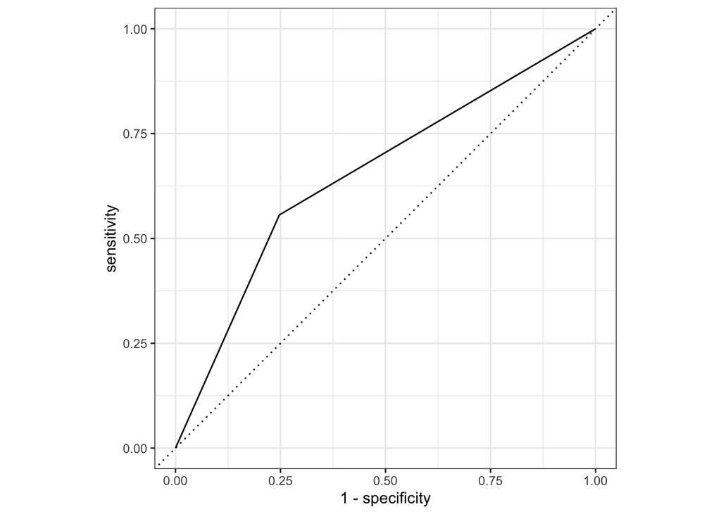

```r
weather_pred1 %>%
  roc_curve(
    truth = RainTomorrow,
    .pred_Yes,
    event_level = "second"
  ) %>%
  autoplot()
```

```r
weather_pred1 %>%
  roc_auc(
    truth = RainTomorrow,
    .pred_Yes,
    event_level = "second"
  )
```

```
## # A tibble: 1 × 3
##   .metric .estimator .estimate
##   <chr>   <chr>          <dbl>
## 1 roc_auc binary         0.654
```

- Create now the ROC curve and get the AUC (area under the curve) value for your second model:

```r
weather_pred2 <- predict(weather_fit2, test_data, type = "prob") %>%
  bind_cols(test_data)
```

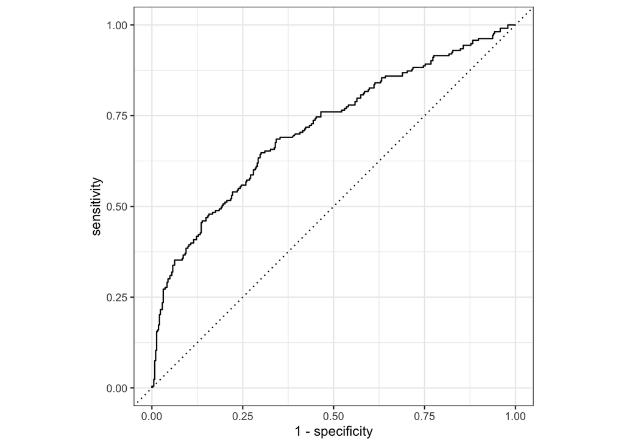

```r
weather_pred2 %>%
  roc_curve(
    truth = RainTomorrow,
    .pred_Yes,
    event_level = "second"
  ) %>%
  autoplot()
```

```r
weather_pred2 %>%
  roc_auc(
    truth = RainTomorrow,
    .pred_Yes,
    event_level = "second"
  )
```

```
## # A tibble: 1 × 3
##   .metric .estimator .estimate
##   <chr>   <chr>          <dbl>
## 1 roc_auc binary         0.714
```

- Which model seems to have a better performance?

The second model, the one with multiple predictors, has a larger AUC. Moreover, its ROC curve is further away from the diagonal compared to the ROC curve of the simpler simple logistic regression model.

4. Now focus on the second model. Consider several thresholds for predicting `RainTomorrow` and look at the number of false positives and false negatives. For example:

```r
cutoff_prob <- 0.5
weather_pred2 %>%
  mutate(
    RainTomorrow      = if_else(RainTomorrow == "Yes", "It rains", "It does not rain"),
    RainTomorrow_pred = if_else(.pred_Yes > cutoff_prob, "Predicted rain", "Predicted no rain")
    ) %>%
  na.omit() %>%
  count(RainTomorrow_pred, RainTomorrow)
```

```
## # A tibble: 4 × 3
##   RainTomorrow_pred RainTomorrow         n
##   <chr>             <chr>            <int>
## 1 Predicted no rain It does not rain   177
## 2 Predicted no rain It rains            62
## 3 Predicted rain    It does not rain    51
## 4 Predicted rain    It rains            76
```

The false positive rate is given by FP / (FP + TN), so `51 / (51+177) = 0.22`.

- What about the false negative rate?

The false negative rate is given by FN / (TP + FN), so `62 / (62+76) = 0.44`.

# Exercise 4: Extend our model [OPTIONAL]

We will now try to improve our fit by building a model using additional explanatory variables.

1. Let us analyze the various variables in our dataset.
- Is there any categorical variable which is very unbalanced?

```r
train_data %>%
  select(where(is.factor), -RainTomorrow, -Location) %>%
  names()
```

```
## [1] "RainToday"
```

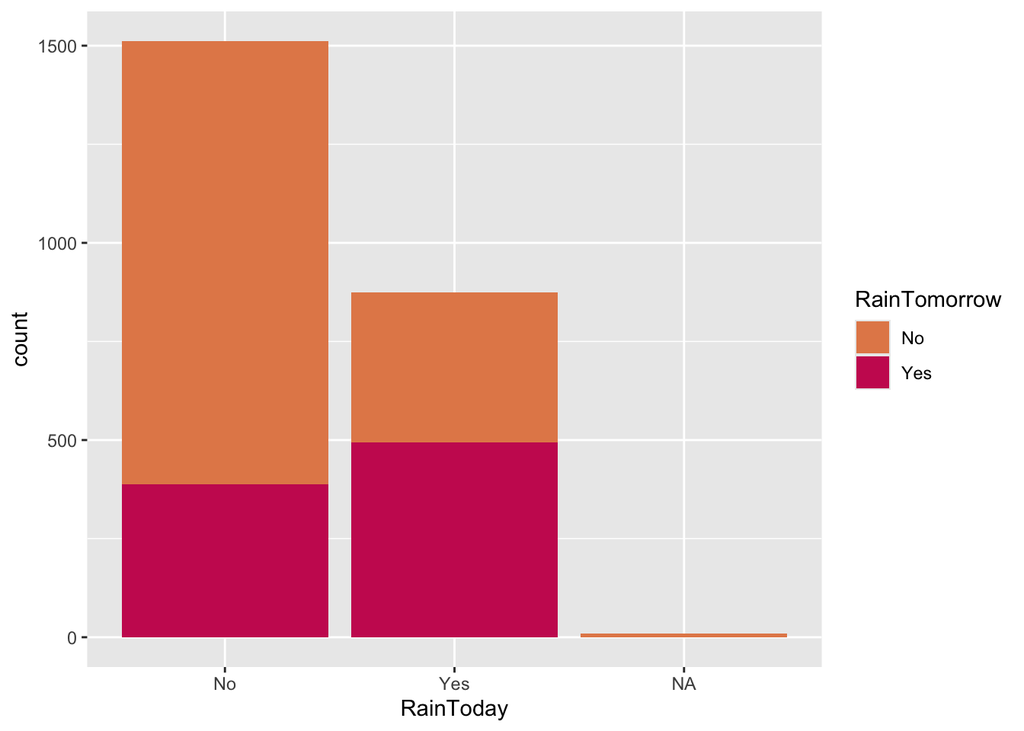

```r
p_RainToday <- ggplot(train_data, aes(x = RainToday, fill = RainTomorrow)) +
  geom_bar() +
  scale_fill_manual(values = c("#E48957", "#CA235F"))

p_RainToday
```

No.

- Is there any numerical variable that has a very small standard deviation for one of the two categories of `RainTomorrow`?

```r
sd_num = train_data %>%
  group_by(RainTomorrow) %>%
  select(where(is.numeric)) %>%
  summarise_all(sd,na.rm=TRUE)
sd_num
```

```
## # A tibble: 2 × 17
##   RainTomorrow MinTemp MaxTemp Rainfall Evaporation Sunshine WindGustSpeed
##   <fct>          <dbl>   <dbl>    <dbl>       <dbl>    <dbl>         <dbl>
## 1 No              3.79    5.43     3.60        2.72     3.82          12.0
## 2 Yes             3.21    4.39     6.74        2.37     2.99          16.6
## # ℹ 10 more variables: WindSpeed9am <dbl>, WindSpeed3pm <dbl>,
## #   Humidity9am <dbl>, Humidity3pm <dbl>, Pressure9am <dbl>, Pressure3pm <dbl>,
## #   Cloud9am <dbl>, Cloud3pm <dbl>, Temp9am <dbl>, Temp3pm <dbl>
```

No, the minimum sd is 1.7879861.

2. Let’s do some feature engineering: let us transform the variable `Date`. We will use `Ludbridate` again: extract the month and year.

```r
library(lubridate)
weather_Portland %>%
  mutate(Date = lubridate::date(Date)) %>%
  mutate(month = factor(month(Date)),
         year = year(Date)) %>%
  select(Date, month, year) %>%
  sample_n(size = 5)
```

```
##         Date month year
## 1 2014-11-03    11 2014
## 2 2015-07-03     7 2015
## 3 2014-07-06     7 2014
## 4 2014-07-24     7 2014
## 5 2009-06-25     6 2009
```

3. Let’s now combine everything into recipes and workflows.

```r
weather_rec3 <- recipe(
  RainTomorrow ~ ., # formula
  data = weather_Portland
  ) %>%
  step_rm(Location) %>%
  step_mutate(Date = lubridate::date(Date)) %>%
  step_date(Date, features = c("month", "year")) %>%
  step_rm(Date) %>%
  step_dummy(all_nominal(), -all_outcomes())
```

```r
weather_mod3 <- logistic_reg() %>%
  set_engine("glm")
```

```r
weather_wflow3 <- workflow() %>%
  add_model(weather_mod3) %>%
  add_recipe(weather_rec3)
```

```r
weather_fit3 <- weather_wflow3 %>%
  fit(data = train_data)
tidy(weather_fit3)
```

```
## # A tibble: 30 × 5
##    term           estimate std.error statistic  p.value
##    <chr>             <dbl>     <dbl>     <dbl>    <dbl>
##  1 (Intercept)   104.       70.7         1.46  1.43e- 1
##  2 MinTemp        -0.143     0.0413     -3.45  5.52e- 4
##  3 MaxTemp        -0.0876    0.0668     -1.31  1.90e- 1
##  4 Rainfall        0.0140    0.0173      0.809 4.19e- 1
##  5 Evaporation     0.0704    0.0455      1.55  1.22e- 1
##  6 Sunshine       -0.0730    0.0276     -2.64  8.30e- 3
##  7 WindGustSpeed   0.0697    0.0104      6.72  1.82e-11
##  8 WindSpeed9am   -0.0191    0.0146     -1.31  1.91e- 1
##  9 WindSpeed3pm   -0.00528   0.0143     -0.368 7.13e- 1
## 10 Humidity9am    -0.00472   0.00751    -0.628 5.30e- 1
## # ℹ 20 more rows
```

```r
weather_pred3 <- predict(weather_fit3, test_data, type = "prob") %>%
  bind_cols(test_data)
```

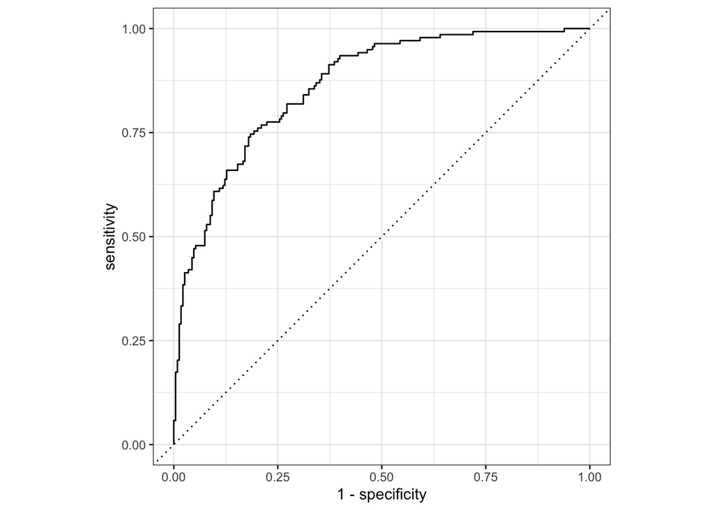

```r
weather_pred3 %>%
  roc_curve(
    truth = RainTomorrow,
    .pred_Yes,
    event_level = "second"
  ) %>%
  autoplot()
```

```r
weather_pred3 %>%
  roc_auc(
    truth = RainTomorrow,
    .pred_Yes,
    event_level = "second"
  )
```

```
## # A tibble: 1 × 3
##   .metric .estimator .estimate
##   <chr>   <chr>          <dbl>
## 1 roc_auc binary         0.864
```

4. Is this model better than the one we fitted in Exercise 3?

Yes, the AUC for this model is higher and the ROC curve is closer to the top-left corner of the plot.